# Assignment 5

Due at 11:59pm on November 28.

You may work in pairs or individually for this assignment. Make sure you join a group in Canvas if you are working in pairs. Turn in this assignment as an HTML or PDF file to ELMS. Make sure to include the R Markdown or Quarto file that was used to generate it. Include the GitHub link for the repository containing these files.

```r
library(censusapi)
library(tidyverse)
library(magrittr)
library(factoextra)
library(stringr)
library(knitr)
```

## Exploring ACS Data

In this notebook, we use the Census API to gather data from the American Community Survey (ACS). This requires an access key, which can be obtained here:

https://api.census.gov/data/key_signup.html

```r
cs_key <- "c0fd12402e23b7a95923e694f046015d624c91c5"
acs_il_c <- getCensus(name = "acs/acs5",
                     vintage = 2016,
                     vars = c("NAME", "B01003_001E", "B19013_001E", "B19301_001E"),
                     region = "county:*",
                     regionin = "state:17",
                     key = cs_key) %>%
             rename(pop = B01003_001E,
                    hh_income = B19013_001E,
                    income = B19301_001E)
kable(head(acs_il_c))
```

| state | county | NAME | pop | hh_income | income |
| --- | --- | --- | --- | --- | --- |
| 17 | 067 | Hancock County, Illinois | 18633 | 50077 | 25647 |
| 17 | 063 | Grundy County, Illinois | 50338 | 67162 | 30232 |
| 17 | 091 | Kankakee County, Illinois | 111493 | 54697 | 25111 |
| 17 | 043 | DuPage County, Illinois | 930514 | 81521 | 40547 |
| 17 | 003 | Alexander County, Illinois | 7051 | 29071 | 16067 |
| 17 | 129 | Menard County, Illinois | 12576 | 60420 | 31323 |

Pull map data for Illinois into a data frame.

```r
il_map <- map_data("county", region = "illinois")
kable(head(il_map))
```

| long | lat | group | order | region | subregion |
| --- | --- | --- | --- | --- | --- |
| -91.49563 | 40.21018 | 1 | 1 | illinois | adams |
| -90.91121 | 40.19299 | 1 | 2 | illinois | adams |
| -90.91121 | 40.19299 | 1 | 3 | illinois | adams |
| -90.91121 | 40.10704 | 1 | 4 | illinois | adams |
| -90.91121 | 39.83775 | 1 | 5 | illinois | adams |
| -90.91694 | 39.75754 | 1 | 6 | illinois | adams |

Join the ACS data with the map data. Not that `il_map` has a column `subregion` which includes county names. We need a corresponding variable in the ACS data to join both data sets. This needs some transformations, among which the function `tolower()` might be useful. Call the joined data `acs_map`.

```r
# transform acs_il_c
acs_il_c$subregion = tolower(str_remove_all(acs_il_c$NAME, " County, Illinois"))
acs_il_c$subregion = str_remove_all(acs_il_c$subregion, " ")
acs_il_c$subregion = str_remove_all(acs_il_c$subregion, "\\.")

# transform il_map
il_map$subregion = tolower(str_remove_all(il_map$subregion, " "))
il_map$subregion = str_remove_all(il_map$subregion, "\\.")

# merge the data
acs_map = left_join(il_map, acs_il_c, by = "subregion")
```

After you do this, plot a map of Illinois with Counties colored by per capita income.

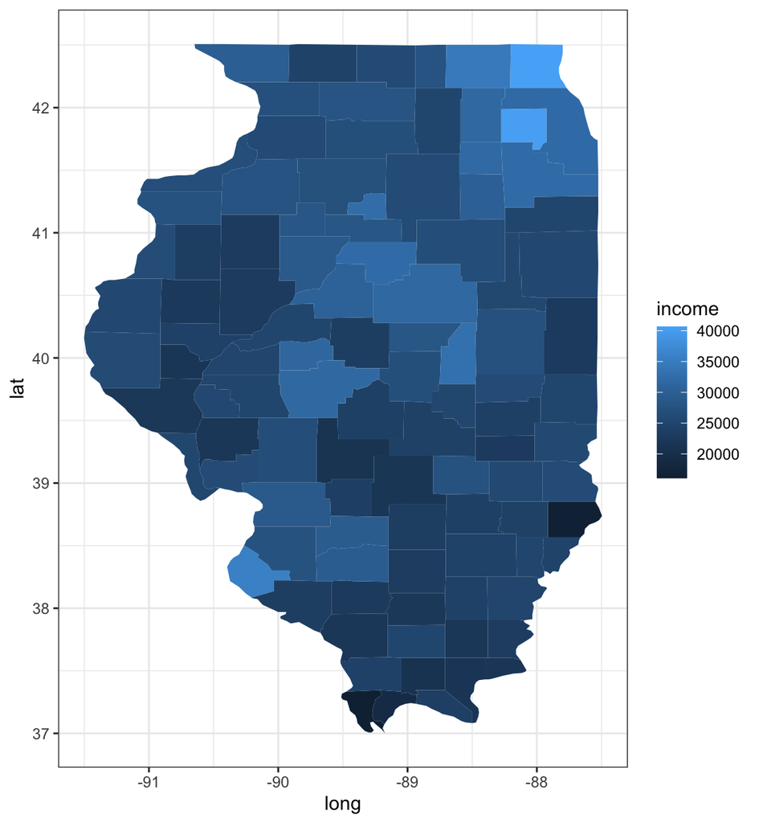

```r
ggplot(acs_map) +
  geom_polygon(aes(x = long, y = lat, group = group, fill = income)) +
  theme_bw()
```

## Hierarchical Clustering

We want to find clusters of counties that are similar in their population, average household income and per capita income. First, clean the data so that you have the appropriate variables to use for clustering. Next, create the distance matrix of the cleaned data. This distance matrix can be used to cluster counties, e.g. using the ward method.

```r
hclust_data = acs_map %>%
  select(pop, hh_income, income) %>%
  mutate_all(scale)
hclust_d = dist(hclust_data)
hc_ward = hclust(hclust_d, method = "ward.D2")
```

Plot the dendrogram to find a reasonable number of clusters. Draw boxes around the clusters of your cluster solution.

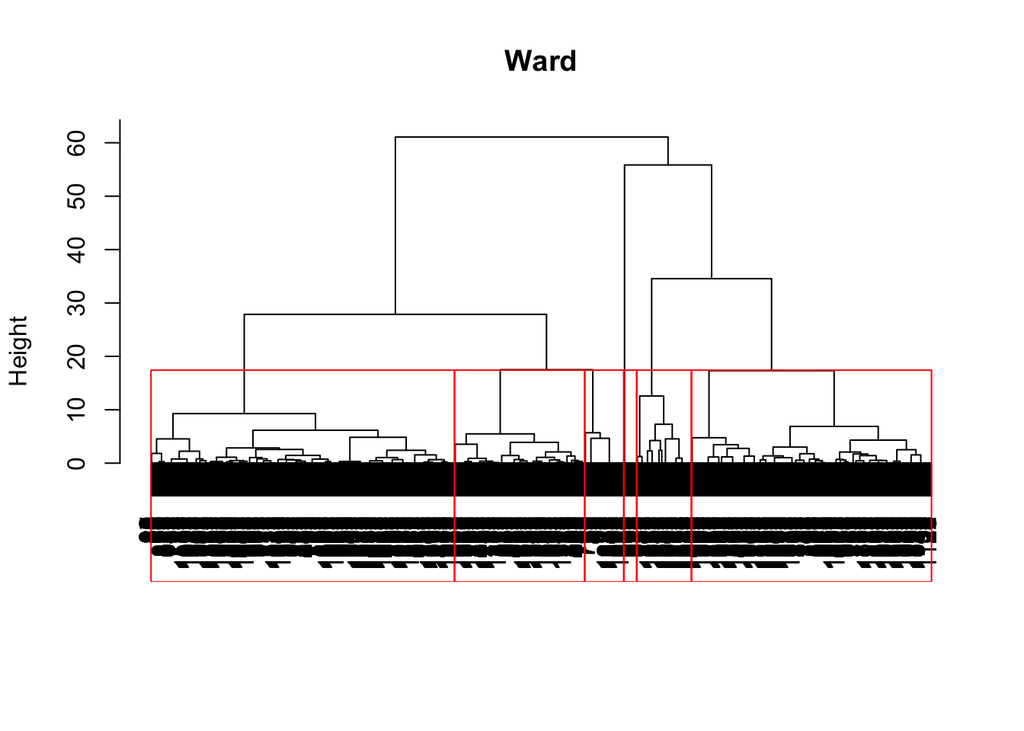

```r
plot(hc_ward, main = "Ward", xlab = "", sub = "")
rect.hclust(hc_ward, k = 6, border = "red")
```

Visualize the county clusters on a map. For this task, create a new `acs_map` object that now also includes cluster membership as a new column. This column should be called `cluster`.

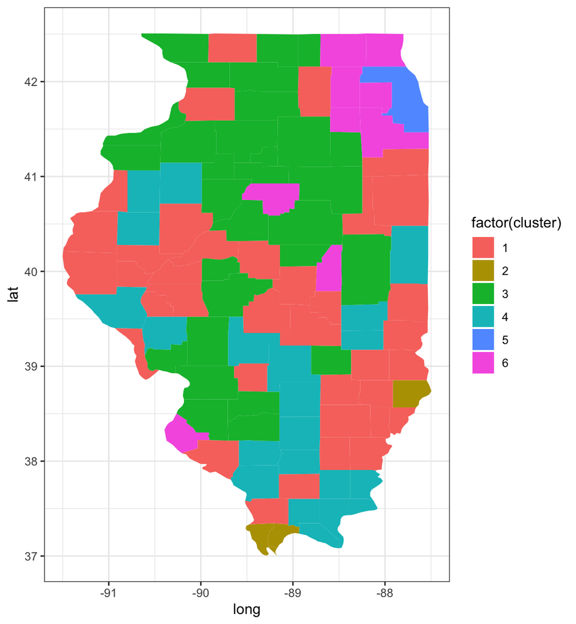

```r
acs_map = acs_map %>%
  mutate(cluster = cutree(hc_ward, 6))

ggplot(acs_map) +
  geom_polygon(aes(x = long, y = lat, group = group, fill = factor(cluster))) +
  theme_bw()
```

## Census Tracts

For the next section we need ACS data on a census tract level. We use the same variables as before.

```r
acs_il_t <- getCensus(name = "acs/acs5",
                      vintage = 2016,
                      vars = c("NAME", "B01003_001E", "B19013_001E", "B19301_001E"),
                      region = "tract:*",
                      regionin = "state:17",
                      key = cs_key) %>%
            mutate_all(list(~ ifelse(. == -666666666, NA, .))) %>%
            rename(pop = B01003_001E,
                   hh_income = B19013_001E,
                   income = B19301_001E)
kable(head(acs_il_t))
```

| state | county | tract | NAME | pop | hh_income | income |
| --- | --- | --- | --- | --- | --- | --- |
| 17 | 031 | 806002 | Census Tract 8060.02, Cook County, Illinois | 7304 | 56975 | 23750 |
| 17 | 031 | 806003 | Census Tract 8060.03, Cook County, Illinois | 7577 | 53769 | 25016 |
| 17 | 031 | 806400 | Census Tract 8064, Cook County, Illinois | 2684 | 62750 | 30154 |
| 17 | 031 | 806501 | Census Tract 8065.01, Cook County, Illinois | 2590 | 53583 | 20282 |
| 17 | 031 | 750600 | Census Tract 7506, Cook County, Illinois | 3594 | 40125 | 18347 |
| 17 | 031 | 310200 | Census Tract 3102, Cook County, Illinois | 1521 | 63250 | 31403 |

## k-Means

As before, clean our data for clustering census tracts based on population, average household income and per capita income.

```r
kclust_data = acs_il_t %>%
  select(pop, hh_income, income) %>%
  na.omit()
```

Since we want to use K Means in this section, we start by determining the optimal number of K that results in Clusters with low within but high between variation. Plot within cluster sums of squares for a range of K (e.g. up to 20).

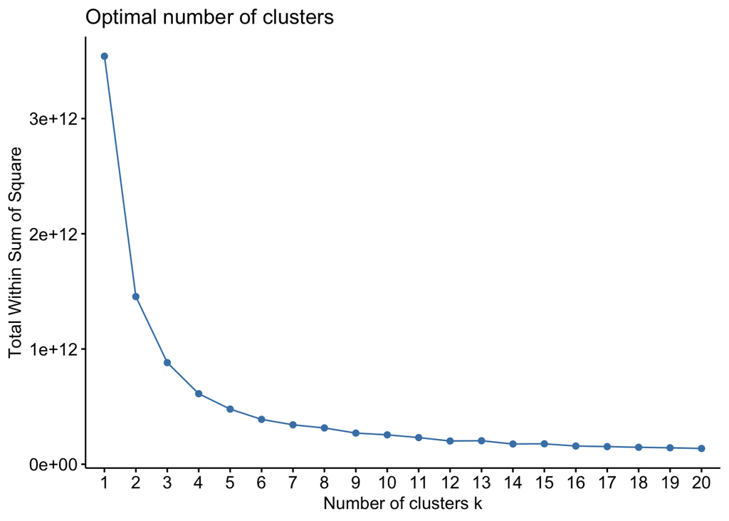

```r
fviz_nbclust(kclust_data, #data set we want to use
             kmeans, #cluster method
             method = "wss", #method used for estimating the optimal number of clusters
             k.max = 20)
```

The optimal number should be 6.

Run `kmeans()` for the optimal number of clusters based on the plot above.

```r
km_1 <- kmeans(kclust_data, 6, nstart = 20)
km_1
```

```
K-means clustering with 6 clusters of sizes 73, 454, 568, 228, 828, 958

Cluster means:
       pop hh_income   income
1 4126.795 163369.92 78493.00
2 5107.751  87549.29 41192.31
3 3023.996  27265.57 15527.79
4 4535.430 112380.92 59990.76
5 4357.746  64282.81 31434.40
6 4029.991  46117.11 23254.56

Clustering vector:
   1    2    3    4    5    6    7    8    9   10   11   12   13   14   15   16
   5    6    5    6    6    5    3    5    3    3    6    6    1    1    1    1
  17   18   19   20   21   22   23   24   25   26   27   28   29   30   31   32
```

[output cut: 396 more lines]

Find the mean population, household income and per capita income grouped by clusters. In addition, display the most frequent county that can be observed within each cluster.

```r
acs_map_t = acs_il_t %>%
  na.omit() %>%
  mutate(cluster = as.factor(km_1$cluster))

acs_map_t_cl = acs_map_t %>% group_by(cluster) %>%
  summarise(m_population = mean(pop),
            m_hhincome = mean(hh_income),
            m_pcincome = mean(income))

kable(acs_map_t_cl, caption = "mean population, household income
      and per capita income grouped by clusters")
```

mean population, household income and per capita income grouped by clusters

| cluster | m_population | m_hhincome | m_pcincome |
| --- | --- | --- | --- |
| 1 | 4126.795 | 163369.92 | 78493.00 |
| 2 | 5107.751 | 87549.29 | 41192.31 |
| 3 | 3023.996 | 27265.57 | 15527.79 |
| 4 | 4535.430 | 112380.92 | 59990.76 |
| 5 | 4357.746 | 64282.81 | 31434.40 |
| 6 | 4029.991 | 46117.11 | 23254.56 |

```r
acs_map_t_county = acs_map_t %>% group_by(cluster, county) %>%
  summarise(n = n()) %>%
  slice(which.max(n))

kable(acs_map_t_county, caption = "the most frequent county that
      can be observed within each cluster")
```

the most frequent county that can be observed within each cluster

| cluster | county | n |
| --- | --- | --- |
| 1 | 031 | 32 |
| 2 | 031 | 177 |
| 3 | 031 | 332 |
| 4 | 031 | 120 |
| 5 | 031 | 281 |
| 6 | 031 | 370 |

As you might have seen earlier, it’s not always clear which number of clusters is the optimal choice. To automate K Means clustering, program a function based on `kmeans()` that takes K as an argument. You can fix the other arguments, e.g. such that a specific dataset is always used when calling the function.

We want to utilize this function to iterate over multiple Ks (e.g., K = 2, …, 10) and -- each time -- add the resulting cluster membership as a new variable to our (cleaned) original data frame (`acs_il_t`). There are multiple solutions for this task, e.g. think about the `apply` family or `for` loops.

Finally, display the first rows of the updated data set (with multiple cluster columns).

```r
apply_kmeans <- function(K, dataset) {
  kmeans_model = kmeans(dataset, centers = K)
  return(kmeans_model$cluster)
}

cluster_list = list()
acs_il_t = acs_il_t %>% na.omit()
acs_il_t_loop = acs_il_t %>% select(pop, hh_income, income)

for(K in 2:10) {
  new_var = paste0("cluster_k_", K)
  clusters = apply_kmeans(K, acs_il_t_loop)
  cluster_list[[new_var]] = clusters
}


cluster_df = as.data.frame(cluster_list)
acs_il_t = cbind(acs_il_t, cluster_df)

kable(head(acs_il_t))
```

| state | county | tract | NAME | pop | hh_income | income | cluster_k_2 | cluster_k_3 | cluster_k_4 | cluster_k_5 | cluster_k_6 | cluster_k_7 | cluster_k_8 | cluster_k_9 | cluster_k_10 |
| --- | --- | --- | --- | --- | --- | --- | --- | --- | --- | --- | --- | --- | --- | --- | --- |
| 17 | 031 | 806002 | Census Tract 8060.02, Cook County, Illinois | 7304 | 56975 | 23750 | 1 | 3 | 1 | 1 | 1 | 7 | 7 | 5 | 5 |
| 17 | 031 | 806003 | Census Tract 8060.03, Cook County, Illinois | 7577 | 53769 | 25016 | 1 | 3 | 1 | 1 | 3 | 3 | 7 | 3 | 5 |
| 17 | 031 | 806400 | Census Tract 8064, Cook County, Illinois | 2684 | 62750 | 30154 | 1 | 1 | 1 | 3 | 1 | 7 | 6 | 5 | 7 |
| 17 | 031 | 806501 | Census Tract 8065.01, Cook County, Illinois | 2590 | 53583 | 20282 | 1 | 3 | 1 | 1 | 3 | 3 | 7 | 3 | 5 |
| 17 | 031 | 750600 | Census Tract 7506, Cook County, Illinois | 3594 | 40125 | 18347 | 1 | 3 | 2 | 5 | 3 | 3 | 1 | 2 | 4 |
| 17 | 031 | 310200 | Census Tract 3102, Cook County, Illinois | 1521 | 63250 | 31403 | 1 | 1 | 1 | 3 | 1 | 7 | 6 | 5 | 7 |